# Project: Test a Perceptual Phenomenon

## Background Information

### In a Stroop task, participants are presented with a list of words, with each word displayed in a color of ink. The participant’s task is to say out loud the color of the ink in which the word is printed. The task has two conditions: a congruent words condition, and an incongruent words condition. In the congruent words condition, the words being displayed are color words whose names match the colors in which they are printed. In the incongruent words condition, the words displayed are color words whose names do not match the colors in which they are printed. In each case, we measure the time it takes to name the ink colors in equally-sized lists. Each participant will go through and record a time from each condition.

## Questions:

1. "What is our independent variable? What is our dependent variable?"
2. "What is an appropriate set of hypotheses for this task? What kind of statistical test do you expect to perform? Justify your choices."
3. "Report some descriptive statistics regarding this dataset. Include at least one measure of central tendency and at least one measure of variability."
4. "Provide one or two visualizations that show the distribution of the sample data. Write one or two sentences noting what you observe about the plot or plots."
5. "Now, perform the statistical test and report your results. What is your confidence level and your critical statistic value? Do you reject the null hypothesis or fail to reject it? Come to a conclusion in terms of the experiment task. Did the results match up with your expectations?"
6. "Optional: What do you think is responsible for the effects observed? Can you think of an alternative or similar task that would result in a similar effect? Some research about the problem will be helpful for thinking about these two questions!"

### 3. What kind of statistical test do you expect to perform? Justify your choices.

#### - I expect to perform a paired sample t-test. I expect this beacause a paired sample t-test is one in which the mean from the same group is compared across different times. Since the participants of the study were measured once for each set of words, at different times, this seems like an appropriate test given how the experiment was conducted.

### 4. Report some descriptive statistics regarding this dataset. Include at least one measure of central tendency and at least one measure of variability.

```python
import pandas as pd
data = pd.read_csv('C:\\Users\\chris\\Desktop\\Udacity files\\Project 5//stroopdata.csv')
data.describe()
```

|  | Congruent | Incongruent |
| --- | --- | --- |
| count | 24.000000 | 24.000000 |
| mean | 14.051125 | 22.015917 |
| std | 3.559358 | 4.797057 |
| min | 8.630000 | 15.687000 |
| 25% | 11.895250 | 18.716750 |
| 50% | 14.356500 | 21.017500 |
| 75% | 16.200750 | 24.051500 |
| max | 22.328000 | 35.255000 |

### From the describe, we can report the mean and standard deviation for our data.

### Central tendency:

#### - Congruent mean = 14.051125

#### - Incongruent mean = 22.015917

### Measure of variability:

#### - Congruent std = 3.559358

#### - Incongruent std = 4.797057

### 5. Provide one or two visualizations that show the distribution of the sample data. Write one or two sentences noting what you observe about the plot or plots.

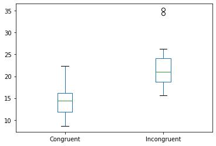

```python
data.plot(kind='box')
```

#### From this box plot, we can see the distribution of our two groups with the graph depicting what we previously observed, the mean on the Incongruent data is higher than the Congruent.

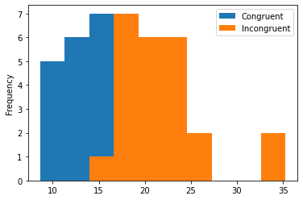

```python
data.plot(kind='hist')
```

#### In our histogram, we again see that the distribution of these two data sets doesn't appear to be equal, with Congruent trending lower than Incongruent.

#### 6. Now, perform the statistical test and report your results. What is your confidence level and your critical statistic value? Do you reject the null hypothesis or fail to reject it? Come to a conclusion in terms of the experiment task. Did the results match up with your expectations?

#### - For this test, we have a confidence level of 95%. We also need our degrees of freedom, which we can calculate from the .describe count from above (24-1 =23).

```python
from scipy import stats
stats.t.ppf(0.95, 23)
```

```
1.7138715277470473
```

#### - Next we perform the ttest on our paired data.

```python
stats.ttest_rel(data['Congruent'], data['Incongruent'])
```

```
Ttest_relResult(statistic=-8.020706944109957, pvalue=4.103000585711178e-08)
```

#### - This shows us we can reject our null hypothesis beause the absolute value of our tstatistic is greater than our critical value.

#### - We can then conclude that the congruent and incongruent groups do take different amounts of time to identify the words caused by the Stroop effect.

#### - These results did match up with my expectations. After seeing the means being so different for the two groups in an earlier question, I thought this would be the result.

### Optional: What do you think is responsible for the effects observed? Can you think of an alternative or similar task that would result in a similar effect? Some research about the problem will be helpful for thinking about these two questions!

#### - I think the way that the brain recognizes colors and words is being manipulated. In one word list, reading and recognizing colors are working together to help the person identify the word, whereas on the other list, those processes are working against one another.

#### - An alternative task could be to measure the amount of time it took a group of users to read a series of numbers in word form where in one set the correct numerals were displayed above the number and in the other a random set of numerals were displayed.